# NYPD Shooting Incident Data Report

2023-02-27

```r
knitr::opts_chunk$set(echo = TRUE)
library(tidyverse)
```

```r
library(ggplot2)
library(dplyr)
library(maps)
```

## Import, Tidy, Analyze and Graph

In this report I will take a look at the NYPD shooting incident data. I found my data at the following site: https://catalog.data.gov/dataset?q=NYPD&sort=views_recent+desc&ext_location=&ext_bbox=&ext_prev_extent=-164.53125%2C-80.17871349622823%2C164.53125%2C80.17871349622823.

My first step was to import the data. The initial dataset had almost 26000 incidents of shootings from the year 2006 to the end of 2021. There were 19 variables (column fields) recorded in the initial data set including demographic and location information for each incident.

To tidy the data, I changed the “Occurence Date” field from a character variable to a date variable. I removed some fields that I didn’t think I would need for my analysis, particularly those fields lacking data for a significant number of incidents.

For my first analysis, I thought it would be interesting to look at the perpetrator age groups and see if there were certain groups that caused more of the shootings. This information could be useful for targeting certain age groups for prevention programs. I took the cumulative shootings per year for each age group. It seemed like there were a handful of erroneous entries that I filtered out as well.

```r
#This Imports NYPD shooting incident data. List shooting incidents occurring in
#NYC from 2006 to 2022

url_in <- "https://data.cityofnewyork.us/api/views/833y-fsy8/rows.csv?accessType=DOWNLOAD"
#this is the original data_frame for NYPD shooting data
shooting_data <- read_csv(url_in)
#creating new df removing unneeded columns
filtered_shooting_data <- subset(shooting_data, select = c(INCIDENT_KEY, OCCUR_DATE,BORO,PERP_AGE_GROUP,Latitude, Longitude))

#changing date variable from char to date and removing any variables with unknown #perpetrator age
filtered_shooting_data <- mutate(filtered_shooting_data, OCCUR_DATE = mdy(OCCUR_DATE))
filtered_shooting_data <- filter(filtered_shooting_data, PERP_AGE_GROUP != 'UNKNOWN')

dat <- aggregate(filtered_shooting_data$PERP_AGE_GROUP,by = list(filtered_shooting_data$PERP_AGE_GROUP, year(filtered_shooting_data$OCCUR_DATE)), FUN = length, simplify = TRUE)
colnames(dat) <-c("Age_Group", "Year", "Total_Incidents")

dat <- dat %>% group_by(Age_Group) %>% filter(n()>1)

#sample of aggregate data
print(dat)
```

```
## # A tibble: 80 × 3
## # Groups:   Age_Group [5]
##    Age_Group  Year Total_Incidents
##    <chr>     <dbl>           <int>
##  1 <18        2006             138
##  2 18-24      2006             498
##  3 25-44      2006             425
##  4 45-64      2006              29
##  5 65+        2006               2
##  6 <18        2007             134
##  7 18-24      2007             479
##  8 25-44      2007             372
##  9 45-64      2007              26
## 10 65+        2007              10
## # … with 70 more rows
```

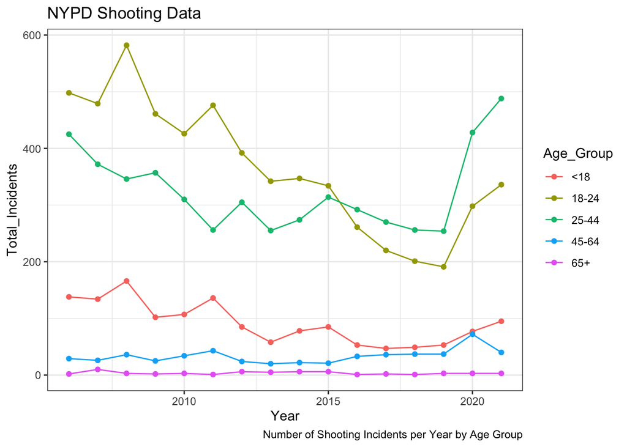

```r
#plotting data
ggplot(dat, aes(x = Year, y = Total_Incidents, color = Age_Group))+geom_line()+labs(title = "NYPD Shooting Data",caption="Number of Shooting Incidents per Year by Age Group", x = "Year")+theme_bw()+geom_point()
```

## Mapping the Data

Since I’m interested in learning more about Geographic Data Science and this data set contained location information, I thought it would be interesting to map out the data to see if there were any trends on where the shooting incidents occurred. With the dataset being so large I choose to focus on a single perpetrator age group range and compare two different years. I choose the perpetrator age group 25-44 since this group has a high number of shooting incidents per year. I also chose to compare two different years for this group- 2019 and 2021. In 2019 the number of shooting incidence for this age were lower than previous years, but in 2021 the number shoot back up.

After spending some time trying to map the data using the ggplot mapping functions with little success, I switched to the maps library. It appears either some of the latitude/longitude data may be incorrect or the mapping function is inaccurate. There are data points that mapped out on water areas, which doesn’t seem correct.

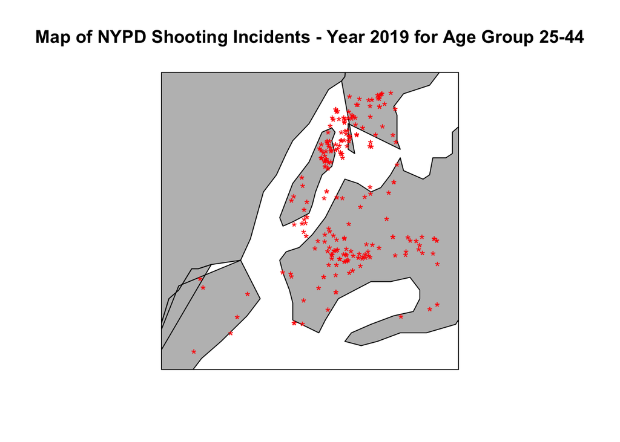

```r
#create map with x and y limits in the range of longitutde and latitude of
#shooting data

map("state", xlim = range(filtered_shooting_data$Longitude), ylim = range(filtered_shooting_data$Latitude), fill= TRUE, col="grey")
box()


#filter shooting data for 25-44 perpetrator age group and then look at two years 2019 &2021
shooting_data_25_44 <- filter(filtered_shooting_data, PERP_AGE_GROUP == '25-44')
shooting_data_25_44_2019 <- subset(shooting_data_25_44, OCCUR_DATE >= "2019-01-01" & OCCUR_DATE < "2020-01-01")
shooting_data_25_44_2021 <- subset(shooting_data_25_44, OCCUR_DATE >= "2021-01-01")

#plotting 2019 shooting incidents for Age Group 25-44
text(shooting_data_25_44_2019$Longitude, shooting_data_25_44_2019$Latitude, '*', col = 'red')
title("Map of NYPD Shooting Incidents - Year 2019 for Age Group 25-44")
```

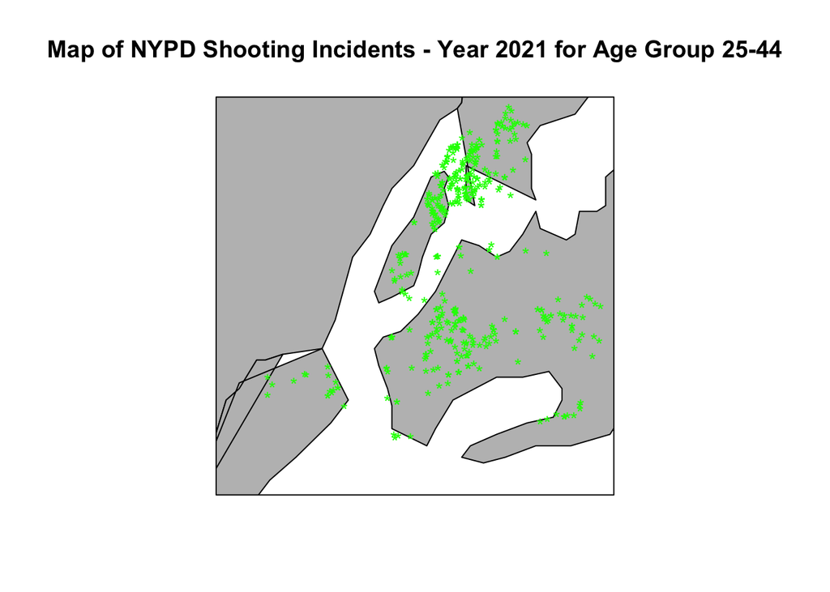

```r
#plotting 2021 shooting incidents for Age Group 25-44
map("state", xlim = range(filtered_shooting_data$Longitude), ylim = range(filtered_shooting_data$Latitude), fill= TRUE, col="grey")
box()
text(shooting_data_25_44_2021$Longitude, shooting_data_25_44_2021$Latitude, '*', col = 'green')
title("Map of NYPD Shooting Incidents - Year 2021 for Age Group 25-44")
```

## Modeling the Data

To create a model for the NYPD dataset, I went back to my initial plot of shootings per year by perpetrator age group. I thought it was interesting that the shootings were trending downward and then rose again after 2019. This makes it hard for a linear model to fit the whole dataset accurately. However, a linear model can fit the last three years of data where shootings incidence have steadily increased. For my model, I again chose to focus on the 25-44 perpetrator age category. After determining a linear model for the data, I plotted the predicted future shooting incidents along with data points for the record incidents from 2019 - 2021.

```r
#filtering for Age Group 25-44 and Year greater than or equal to 2019
age_group_data <- filter(dat, Age_Group == '25-44', Year >=2019)
#To make the model cleaner, I'm using just the last two digits for year
age_group_data$trunc_year <- (age_group_data$Year - 2000)
#create linear model
mod <-lm(Total_Incidents ~ trunc_year, data = age_group_data)
summary(mod)
```

```
##
## Call:
## lm(formula = Total_Incidents ~ trunc_year, data = age_group_data)
##
## Residuals:
##   1   2   3
## -19  38 -19
##
## Coefficients:
##             Estimate Std. Error t value Pr(>|t|)
## (Intercept) -1950.00     658.73  -2.960    0.207
## trunc_year    117.00      32.91   3.555    0.175
##
## Residual standard error: 46.54 on 1 degrees of freedom
## Multiple R-squared:  0.9267, Adjusted R-squared:  0.8534
## F-statistic: 12.64 on 1 and 1 DF,  p-value: 0.1746
```

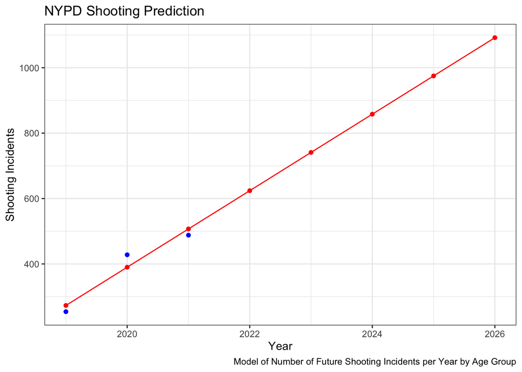

```r
#use the model to add new rows for future years and column for
#modeled prediction
pred_rows <-data.frame(Age_Group='25-44', Year=c(2022,2023,2024,2025,2026), trunc_year=c(22,23,24,25,26), stringsAsFactors = FALSE)
age_group_data<-rbind(age_group_data,pred_rows)
age_group_data <- mutate(age_group_data, pred=117*age_group_data$trunc_year-1950)

#plot the model
p <- ggplot(age_group_data, aes(x = Year, y = pred))+geom_line(color='red')
p+labs(title = "NYPD Shooting Prediction",caption="Model of Number of Future Shooting Incidents per Year by Age Group", x = "Year", y="Shooting Incidents")+theme_bw()+geom_point(color='red')+geom_point(data=age_group_data, aes(x=Year, y = Total_Incidents), color='blue')
```

## Conclusion

Although my model is based on just the last three years of data, the predicted model does fit the recorded incidents nicely. Without intervention, shooting incidents could increase to over 1000 shootings per year for the 25-44 perpetrator age group. Intervention programs should focus on this perpetrator age group to help reverse the trend.

When making conclusions on data analysis, it’s important to consider bias in the data. This dataset in particular has demographic information such as race, age and potentially socioeconomic implied with location information. There could be bias in the way the data is reported as well.It is important to understand the ethics behind analyzing, reporting and modeling this information. One bias I can see in my model would be circumstantial bias. Between the years 2019 and 2021 the combination of a global pandemic, job loss, social, political and economic unrest could have all factored into increased shootings. It’s possible that once these factors stabilize, shooting incidents will stabilize or decrease.